# Practical Machine Learning Project

Student 1, Practical Machine Learning, Coursera

October 21, 2014

## NOTE: I could not get my code to work. I am submitting the work as is. Apologies.

1. **Predicting the manner of a Weight Lifting Exercise** The goal of this project is to predict the manner of a Weight Lifting Exercise. The Training Dataset has 19,622 rows and 160 variables. The variable “classe” (variable 160) is the response, and any of the other 159 variables can be used as predictors. The “classe” variable can take on five different values: A, B, C, D and E. Class A is the “right way” to exercise; the other 4 classes represent various mistakes.

Question: Predict how well the exercise was performed (as determined by the “classe” variable) based on a set of data from accelerometers, gyroscopes and magnetometers placed on the belt, forearm, arm and dumbell.

## Approach, Discussion and Modeling

The approach to analysis will be as follows:

1. **Cross-Validation** In this step, we will split the Training Data Set (as provided in pml-training.csv) further into a Train and Test Dataset. We use the caret package and the createDataPartition function. We will also use the nearZeroVar to identify and remove any zero covariates. We also create two new data frames – newtraining and newtesting that do not have the zero covariates. In order to apply PCA, we need to convert factor variables into numeric for both training and testing datasets.

```r
library(caret)
setwd("Training Data")
set.seed(3434)
myData <- read.csv("pml-training.csv", header = TRUE)
inTrain <- createDataPartition(y = myData$classe, p = 0.75, list = FALSE)
training <- myData[inTrain,]
testing <- myData[-inTrain,]
nsv <- nearZeroVar(training, saveMetrics = TRUE)
nsv
```

```
##                          freqRatio percentUnique zeroVar   nzv
## X                            1.000     100.00000   FALSE FALSE
## user_name                    1.096       0.04077   FALSE FALSE
## raw_timestamp_part_1         1.031       5.68012   FALSE FALSE
## raw_timestamp_part_2         1.000      88.63297   FALSE FALSE
## cvtd_timestamp               1.014       0.13589   FALSE FALSE
## new_window                  48.892       0.01359   FALSE  TRUE
## num_window                   1.031       5.81601   FALSE FALSE
## roll_belt                    1.086       7.67767   FALSE FALSE
## pitch_belt                   1.055      11.63202   FALSE FALSE
## yaw_belt                     1.091      12.50170   FALSE FALSE
## total_accel_belt             1.068       0.19024   FALSE FALSE
## kurtosis_roll_belt        2060.429       1.97038   FALSE  TRUE
## kurtosis_picth_belt        627.087       1.66463   FALSE  TRUE
## kurtosis_yaw_belt           48.892       0.01359   FALSE  TRUE
## skewness_roll_belt        2060.429       1.94999   FALSE  TRUE
## skewness_roll_belt.1       627.087       1.73937   FALSE  TRUE
## skewness_yaw_belt           48.892       0.01359   FALSE  TRUE
## max_roll_belt                1.250       1.10069   FALSE FALSE
## max_picth_belt               1.531       0.13589   FALSE FALSE
## max_yaw_belt               534.185       0.39408   FALSE  TRUE
## min_roll_belt                1.111       1.05313   FALSE FALSE
## min_pitch_belt               2.103       0.10192   FALSE FALSE
## min_yaw_belt               534.185       0.39408   FALSE  TRUE
## amplitude_roll_belt          1.174       0.78815   FALSE FALSE
## amplitude_pitch_belt         2.981       0.08833   FALSE FALSE
## amplitude_yaw_belt          51.695       0.02718   FALSE  TRUE
## var_total_accel_belt         1.717       0.33972   FALSE FALSE
## avg_roll_belt                1.091       1.03275   FALSE FALSE
## stddev_roll_belt             1.000       0.40087   FALSE FALSE
## var_roll_belt                1.516       0.46202   FALSE FALSE
## avg_pitch_belt               1.000       1.18902   FALSE FALSE
## stddev_pitch_belt            1.087       0.25819   FALSE FALSE
## var_pitch_belt               1.186       0.33972   FALSE FALSE
## avg_yaw_belt                 1.111       1.28414   FALSE FALSE
## stddev_yaw_belt              1.649       0.31254   FALSE FALSE
## var_yaw_belt                 1.548       0.77456   FALSE FALSE
## gyros_belt_x                 1.040       0.89007   FALSE FALSE
## gyros_belt_y                 1.141       0.44843   FALSE FALSE
## gyros_belt_z                 1.029       1.13467   FALSE FALSE
```

[output cut: 106 more lines]

```
## stddev_pitch_forearm        60.000       1.60348   FALSE  TRUE
## var_pitch_forearm           30.000       1.59668   FALSE  TRUE
## avg_yaw_forearm             60.000       1.60348   FALSE  TRUE
## stddev_yaw_forearm          61.000       1.59668   FALSE  TRUE
## var_yaw_forearm             61.000       1.59668   FALSE  TRUE
## gyros_forearm_x              1.081       1.95679   FALSE FALSE
## gyros_forearm_y              1.024       4.92594   FALSE FALSE
## gyros_forearm_z              1.086       2.00435   FALSE FALSE
## accel_forearm_x              1.028       5.29284   FALSE FALSE
## accel_forearm_y              1.013       6.69249   FALSE FALSE
## accel_forearm_z              1.057       3.86601   FALSE FALSE
## magnet_forearm_x             1.172       9.89265   FALSE FALSE
## magnet_forearm_y             1.185      12.52888   FALSE FALSE
## magnet_forearm_z             1.023      11.08846   FALSE FALSE
## classe                       1.469       0.03397   FALSE FALSE
```

```r
table(nsv$nzv)
```

```
##
## FALSE  TRUE
##   103    57
```

```r
c <- 1
j <- 1
for (i in 1:nrow(nsv)) {
   if (!nsv[i, "nzv"]) {
        c[j] <- i
        j <- j + 1
   }
}

for (i in 1:ncol(training)) {
    if (class(training[,i]) == "factor") {
        training[,i] <- as.numeric(training[,i])
    }
}

for (i in 1:ncol(testing)) {
    if (class(testing[,i]) == "factor") {
        testing[,i] <- as.numeric(testing[,i])
    }
}

newtraining <- data.frame(x = training[, c[1]])
newtesting <- data.frame(x = testing[, c[1]])

j <- 1

for (i in 1: length(c)) {
    newtraining[,i] <- training[,c[j]]
    newtesting[,i] <- testing[,c[j]]
    j <- j + 1
}

myNames <- character()
j <- 1
for (j in 1: length(c)) {
    myNames[j] <- names(training)[c[j]]
}
colnames(newtraining) <- myNames
colnames(newtesting) <- myNames
```

2. **Covariate Selection** The new dataset (newtraining) has 103 variables after removing zero covariates, and there are 102 potential predictors. We may want to perform a Principal Component Analysis to check if there are fewer variables that could help in the classification.

NOTE: I could not get the PCA to work.

3. **Finalizing the predictor variables**. We next perform a correlation analysis to see which variables are correlated with each other. This will help in reducing the number of potential predictors required.

```r
M <- abs(cor(newtraining[,7:102]))
diag(M) <- 0
which(M > 0.8,arr.ind=T)
```

```
##                  row col
## yaw_belt           3   1
## total_accel_belt   4   1
## accel_belt_y      25   1
## accel_belt_z      26   1
## accel_belt_x      24   2
## magnet_belt_x     27   2
## roll_belt          1   3
## roll_belt          1   4
## accel_belt_y      25   4
## accel_belt_z      26   4
## pitch_belt         2  24
## magnet_belt_x     27  24
## roll_belt          1  25
## total_accel_belt   4  25
## accel_belt_z      26  25
## roll_belt          1  26
## total_accel_belt   4  26
## accel_belt_y      25  26
## pitch_belt         2  27
## accel_belt_x      24  27
## gyros_arm_y       36  35
## gyros_arm_x       35  36
## magnet_arm_x      41  38
## accel_arm_x       38  41
## magnet_arm_z      43  42
## magnet_arm_y      42  43
## accel_dumbbell_x  74  52
## accel_dumbbell_z  76  53
## gyros_dumbbell_z  73  71
## gyros_forearm_z   90  71
## gyros_dumbbell_x  71  73
## gyros_forearm_z   90  73
## pitch_dumbbell    52  74
## yaw_dumbbell      53  76
## gyros_forearm_z   90  89
## gyros_dumbbell_x  71  90
## gyros_dumbbell_z  73  90
## gyros_forearm_y   89  90
```

4. **Discussion:** Looking at the data variable names, it appears that the following variables may make good predictors of the Class: roll_belt, accel_belt_x, total_accel_belt, gyros_arm_x, accel_arm_x, accel_forearm_x, accel_dumbbell_x.

These predictors, taken by themselves, are extremely weak. Please see some sample predictor plots below:

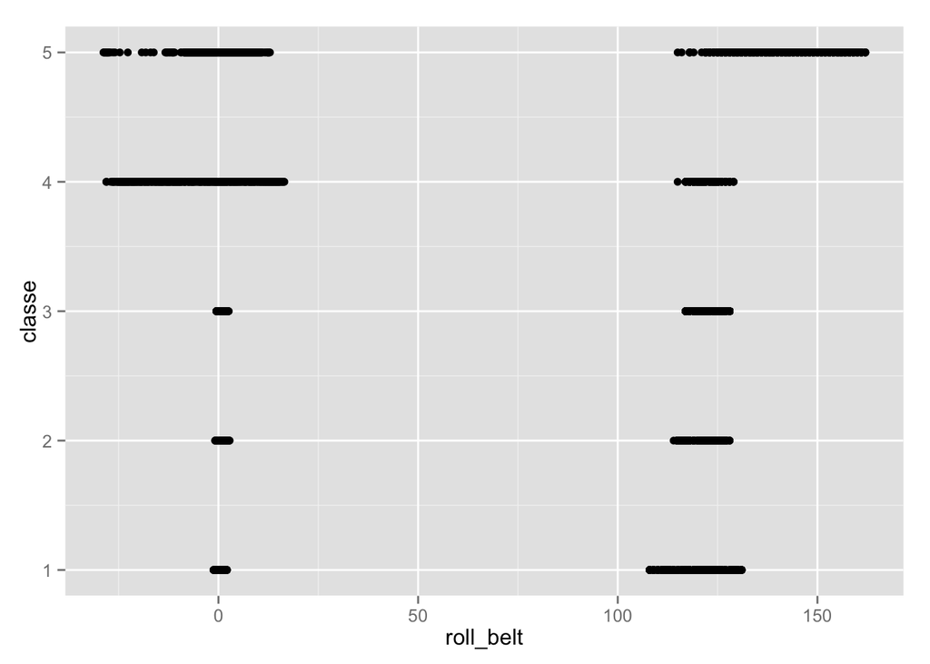

```r
qplot(roll_belt, classe, data=training)
```

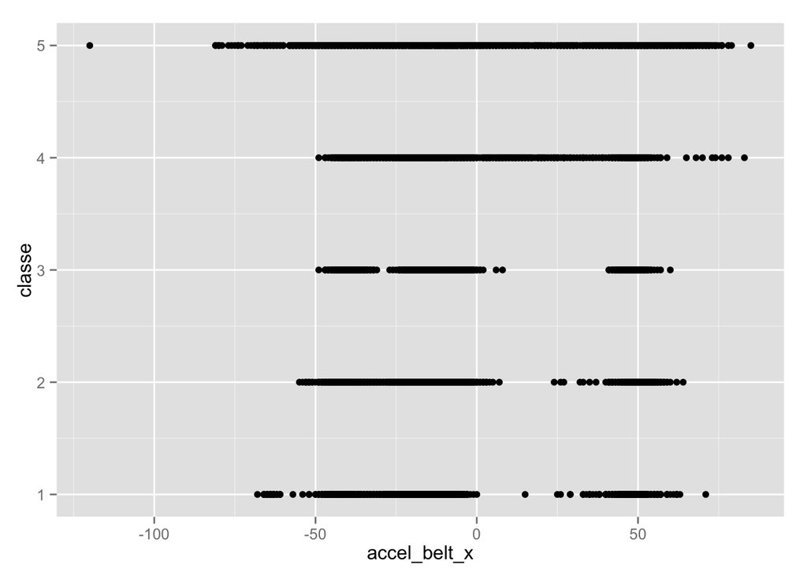

```r
qplot(accel_belt_x, classe, data=training)
```

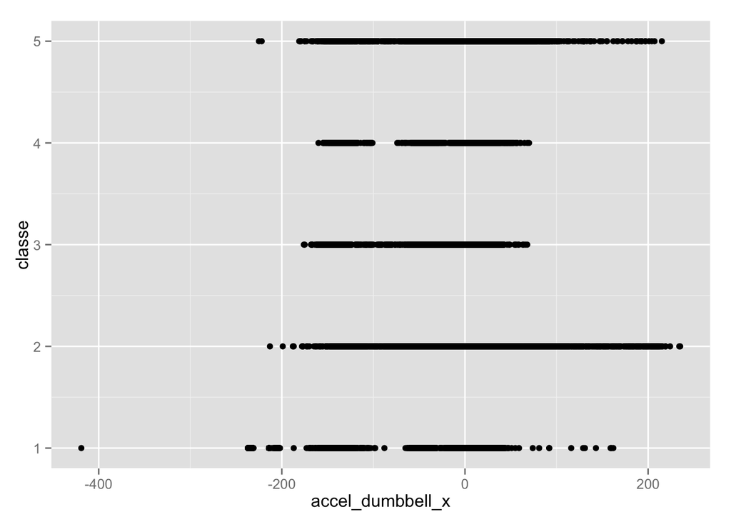

```r
qplot(accel_dumbbell_x, classe, data=training)
```

We select the Random Forest algorithm for predicting the classe. However, I could not get Random Forest to work. I am trying method = “glm” instead.

```r
modelFit <- train(newtraining$classe ~ roll_belt + accel_belt_x + total_accel_belt + gyros_arm_x + accel_arm_x + accel_forearm_x + accel_dumbbell_x, method = "glm", data = newtraining)
```